# Data Exploration

Group 6

Members (Student ID/Email): Abigail Keller (2026918, akelle30@depaul.edu), Kara Faciszewski (1976775, kfacisze@depaul.edu), Joel Fernandez (1394698, jferna26@depaul.edu), Elizabeth Kerrigan (1994142, ekerrig3@depaul.edu). Srinath V.S. (1979936 , SVANAMAM@depaul.edu)

```python
# Import statements
import numpy as np
import pandas as pd
import seaborn as sns
import matplotlib.pyplot as plt

# Display options
pd.set_option('display.max_columns', None)
```

```python
hr_employee_attrition = pd.read_csv( "./Data/WA_Fn-UseC_-HR-Employee-Attrition.csv", delimiter = ",")
```

## Functions

```python
# Function:    numericalStatsGraphs
# Input:       numerical attribute
# Output:      statistics and a histogram
def numericalStatsGraphs(numerical_attribute):
    print('dtype: ',hr_employee_attrition[numerical_attribute].dtypes[0])
    print('Mean:   {:,.3f}'.format(hr_employee_attrition[numerical_attribute].mean().values[0]))
    print('Median: {}'.format(hr_employee_attrition[numerical_attribute].median().values[0]))
    print('Mode:  {}'.format(hr_employee_attrition[numerical_attribute].mode().to_string(header=None,index=False)))
    print('STD:    {:,.3f}'.format(hr_employee_attrition[numerical_attribute].std().values[0]))
    print('Min:    {:,.3f}'.format(hr_employee_attrition[numerical_attribute].min().values[0]))
    # calculate quartile values
    q25, q50, q75 = np.percentile(hr_employee_attrition[numerical_attribute], [25, 50, 75])
    print('25%:    {:,.3f}'.format(q25))
    print('50%:    {:,.3f}'.format(q50))
    print('75%:    {:,.3f}'.format(q75))
    print('Max:    {:,.3f}'.format(hr_employee_attrition[numerical_attribute].max().values[0]))
    print('Skew:   {:,.3f}'.format(hr_employee_attrition[numerical_attribute].skew().values[0]))
    # print histogram
    hr_employee_attrition[numerical_attribute].plot(kind="hist", bins=20)
```

```python
# Function:    correlationMatrix
# Input:       data frame object
# Output:      correlation matrix
# Return:      data frame correlations
# URL:         https://seaborn.pydata.org/examples/many_pairwise_correlations.html
def correlationMatrix(dataframe):
    dataframe_corr = dataframe.corr(method='pearson')
    # Generate a mask for the upper triangle
    mask = np.triu(np.ones_like(dataframe_corr, dtype=bool))
    # Set up the matplotlib figure
    f, ax = plt.subplots(figsize=(11, 9))
    # Generate a custom diverging colormap
    cmap = sns.diverging_palette(230, 20, as_cmap=True)
    # Draw the heatmap with the mask and correct aspect ratio
    sns.heatmap(dataframe_corr, mask=mask, cmap=cmap, vmax=1.0, center=0,
            square=True, linewidths=.5, cbar_kws={"shrink": .5})
    return dataframe_corr
```

## Snapshot

```python
hr_employee_attrition.head(10)
```

|  | Age | Attrition | BusinessTravel | DailyRate | Department | DistanceFromHome | Education | EducationField | EmployeeCount | EmployeeNumber | EnvironmentSatisfaction | Gender | HourlyRate | JobInvolvement | JobLevel | JobRole | JobSatisfaction | MaritalStatus | MonthlyIncome | MonthlyRate | NumCompaniesWorked | Over18 | OverTime | PercentSalaryHike | PerformanceRating | RelationshipSatisfaction | StandardHours | StockOptionLevel | TotalWorkingYears | … |
| --- | --- | --- | --- | --- | --- | --- | --- | --- | --- | --- | --- | --- | --- | --- | --- | --- | --- | --- | --- | --- | --- | --- | --- | --- | --- | --- | --- | --- | --- | --- |
| 0 | 41 | Yes | Travel_Rarely | 1102 | Sales | 1 | 2 | Life Sciences | 1 | 1 | 2 | Female | 94 | 3 | 2 | Sales Executive | 4 | Single | 5993 | 19479 | 8 | Y | Yes | 11 | 3 | 1 | 80 | 0 | 8 | … |
| 1 | 49 | No | Travel_Frequently | 279 | Research & Development | 8 | 1 | Life Sciences | 1 | 2 | 3 | Male | 61 | 2 | 2 | Research Scientist | 2 | Married | 5130 | 24907 | 1 | Y | No | 23 | 4 | 4 | 80 | 1 | 10 | … |
| 2 | 37 | Yes | Travel_Rarely | 1373 | Research & Development | 2 | 2 | Other | 1 | 4 | 4 | Male | 92 | 2 | 1 | Laboratory Technician | 3 | Single | 2090 | 2396 | 6 | Y | Yes | 15 | 3 | 2 | 80 | 0 | 7 | … |
| 3 | 33 | No | Travel_Frequently | 1392 | Research & Development | 3 | 4 | Life Sciences | 1 | 5 | 4 | Female | 56 | 3 | 1 | Research Scientist | 3 | Married | 2909 | 23159 | 1 | Y | Yes | 11 | 3 | 3 | 80 | 0 | 8 | … |
| 4 | 27 | No | Travel_Rarely | 591 | Research & Development | 2 | 1 | Medical | 1 | 7 | 1 | Male | 40 | 3 | 1 | Laboratory Technician | 2 | Married | 3468 | 16632 | 9 | Y | No | 12 | 3 | 4 | 80 | 1 | 6 | … |
| 5 | 32 | No | Travel_Frequently | 1005 | Research & Development | 2 | 2 | Life Sciences | 1 | 8 | 4 | Male | 79 | 3 | 1 | Laboratory Technician | 4 | Single | 3068 | 11864 | 0 | Y | No | 13 | 3 | 3 | 80 | 0 | 8 | … |
| 6 | 59 | No | Travel_Rarely | 1324 | Research & Development | 3 | 3 | Medical | 1 | 10 | 3 | Female | 81 | 4 | 1 | Laboratory Technician | 1 | Married | 2670 | 9964 | 4 | Y | Yes | 20 | 4 | 1 | 80 | 3 | 12 | … |
| 7 | 30 | No | Travel_Rarely | 1358 | Research & Development | 24 | 1 | Life Sciences | 1 | 11 | 4 | Male | 67 | 3 | 1 | Laboratory Technician | 3 | Divorced | 2693 | 13335 | 1 | Y | No | 22 | 4 | 2 | 80 | 1 | 1 | … |
| 8 | 38 | No | Travel_Frequently | 216 | Research & Development | 23 | 3 | Life Sciences | 1 | 12 | 4 | Male | 44 | 2 | 3 | Manufacturing Director | 3 | Single | 9526 | 8787 | 0 | Y | No | 21 | 4 | 2 | 80 | 0 | 10 | … |
| 9 | 36 | No | Travel_Rarely | 1299 | Research & Development | 27 | 3 | Medical | 1 | 13 | 3 | Male | 94 | 3 | 2 | Healthcare Representative | 3 | Married | 5237 | 16577 | 6 | Y | No | 13 | 3 | 2 | 80 | 2 | 17 | … |

```python
hr_employee_attrition.tail(10)
```

|  | Age | Attrition | BusinessTravel | DailyRate | Department | DistanceFromHome | Education | EducationField | EmployeeCount | EmployeeNumber | EnvironmentSatisfaction | Gender | HourlyRate | JobInvolvement | JobLevel | JobRole | JobSatisfaction | MaritalStatus | MonthlyIncome | MonthlyRate | NumCompaniesWorked | Over18 | OverTime | PercentSalaryHike | PerformanceRating | RelationshipSatisfaction | StandardHours | StockOptionLevel | TotalWorkingYears | … |
| --- | --- | --- | --- | --- | --- | --- | --- | --- | --- | --- | --- | --- | --- | --- | --- | --- | --- | --- | --- | --- | --- | --- | --- | --- | --- | --- | --- | --- | --- | --- |
| 1460 | 29 | No | Travel_Rarely | 468 | Research & Development | 28 | 4 | Medical | 1 | 2054 | 4 | Female | 73 | 2 | 1 | Research Scientist | 1 | Single | 3785 | 8489 | 1 | Y | No | 14 | 3 | 2 | 80 | 0 | 5 | … |
| 1461 | 50 | Yes | Travel_Rarely | 410 | Sales | 28 | 3 | Marketing | 1 | 2055 | 4 | Male | 39 | 2 | 3 | Sales Executive | 1 | Divorced | 10854 | 16586 | 4 | Y | Yes | 13 | 3 | 2 | 80 | 1 | 20 | … |
| 1462 | 39 | No | Travel_Rarely | 722 | Sales | 24 | 1 | Marketing | 1 | 2056 | 2 | Female | 60 | 2 | 4 | Sales Executive | 4 | Married | 12031 | 8828 | 0 | Y | No | 11 | 3 | 1 | 80 | 1 | 21 | … |
| 1463 | 31 | No | Non-Travel | 325 | Research & Development | 5 | 3 | Medical | 1 | 2057 | 2 | Male | 74 | 3 | 2 | Manufacturing Director | 1 | Single | 9936 | 3787 | 0 | Y | No | 19 | 3 | 2 | 80 | 0 | 10 | … |
| 1464 | 26 | No | Travel_Rarely | 1167 | Sales | 5 | 3 | Other | 1 | 2060 | 4 | Female | 30 | 2 | 1 | Sales Representative | 3 | Single | 2966 | 21378 | 0 | Y | No | 18 | 3 | 4 | 80 | 0 | 5 | … |
| 1465 | 36 | No | Travel_Frequently | 884 | Research & Development | 23 | 2 | Medical | 1 | 2061 | 3 | Male | 41 | 4 | 2 | Laboratory Technician | 4 | Married | 2571 | 12290 | 4 | Y | No | 17 | 3 | 3 | 80 | 1 | 17 | … |
| 1466 | 39 | No | Travel_Rarely | 613 | Research & Development | 6 | 1 | Medical | 1 | 2062 | 4 | Male | 42 | 2 | 3 | Healthcare Representative | 1 | Married | 9991 | 21457 | 4 | Y | No | 15 | 3 | 1 | 80 | 1 | 9 | … |
| 1467 | 27 | No | Travel_Rarely | 155 | Research & Development | 4 | 3 | Life Sciences | 1 | 2064 | 2 | Male | 87 | 4 | 2 | Manufacturing Director | 2 | Married | 6142 | 5174 | 1 | Y | Yes | 20 | 4 | 2 | 80 | 1 | 6 | … |
| 1468 | 49 | No | Travel_Frequently | 1023 | Sales | 2 | 3 | Medical | 1 | 2065 | 4 | Male | 63 | 2 | 2 | Sales Executive | 2 | Married | 5390 | 13243 | 2 | Y | No | 14 | 3 | 4 | 80 | 0 | 17 | … |
| 1469 | 34 | No | Travel_Rarely | 628 | Research & Development | 8 | 3 | Medical | 1 | 2068 | 2 | Male | 82 | 4 | 2 | Laboratory Technician | 3 | Married | 4404 | 10228 | 2 | Y | No | 12 | 3 | 1 | 80 | 0 | 6 | … |

## Number Of Rows & Colums

```python
print('Rows:   ', hr_employee_attrition.shape[0])
print('Columns:', hr_employee_attrition.shape[1])
```

```
Rows:    1470
Columns: 35
```

## Statistical Summaries And Data Visualizations

### Age:

- Employee's Age.
- Numerical (Discrete).
- Not normally distributed, appears to skew to the right.

```
dtype:  int64
Mean:   36.924
Median: 36.0
Mode:   35
STD:    9.135
Min:    18.000
25%:    30.000
50%:    36.000
75%:    43.000
Max:    60.000
Skew:   0.413
```

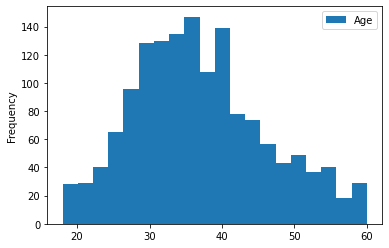

```python
numericalStatsGraphs(['Age'])
```

### Attrition :

- Employee left/leaving the company? (Yes/No).
- Categorical (Nominal).
- There is some class imbalance.
- Need additional Pre-Processing:
  - Class Label, will be dropped from the dataframe.

```
dtype:   object
No:      0.839
Yes:     0.161
```

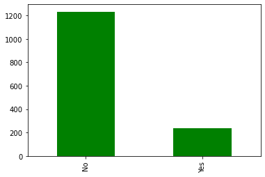

```python
#print(hr_employee_attrition['Attrition'].value_counts())
print('dtype:  ',hr_employee_attrition['Attrition'].dtypes)
print('No:      {:,.3f}'.format(hr_employee_attrition['Attrition'].value_counts()[0]/hr_employee_attrition.shape[0]))
print('Yes:     {:,.3f}'.format(hr_employee_attrition['Attrition'].value_counts()[1]/hr_employee_attrition.shape[0]))
hr_employee_attrition['Attrition'].value_counts().plot(kind='bar', color='green')
```

### BusinessTravel:

- Frequency of travel. (Non-Travel/Travel_Rarely/Travel_Frequently).
- Categorical (Nominal).
- There is some class imbalance.
- Need additional Pre-Processing:
  - Dummy/OneHot encoding.

```
dtype:                object
Travel_Rarely:        0.710
Travel_Frequently:    0.188
Non-Travel:           0.102
```

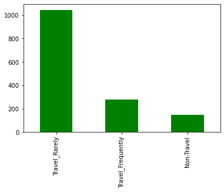

```python
#print(hr_employee_attrition['BusinessTravel'].value_counts())
print('dtype:               ',hr_employee_attrition['BusinessTravel'].dtypes)
print('Travel_Rarely:        {:,.3f}'.format(hr_employee_attrition['BusinessTravel'].value_counts()[0]/hr_employee_attrition.shape[0]))
print('Travel_Frequently:    {:,.3f}'.format(hr_employee_attrition['BusinessTravel'].value_counts()[1]/hr_employee_attrition.shape[0]))
print('Non-Travel:           {:,.3f}'.format(hr_employee_attrition['BusinessTravel'].value_counts()[2]/hr_employee_attrition.shape[0]))
hr_employee_attrition['BusinessTravel'].value_counts().plot(kind='bar', color='green')
```

### DailyRate:

- Daily salary rate.
- Numerical (Continuous).
- Not normally distributed, appears to be sparse.

```
dtype:  int64
Mean:   802.486
Median: 802.0
Mode:   691
STD:    403.509
Min:    102.000
25%:    465.000
50%:    802.000
75%:    1,157.000
Max:    1,499.000
Skew:   -0.004
```

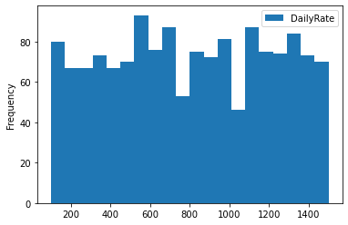

```python
numericalStatsGraphs(['DailyRate'])
```

### Department:

- Department name. (Human Resources/Research & Development/Sales).
- Categorical (Nominal).
- There is some class imbalance.
- Need additional Pre-Processing:
  - Dummy/OneHot encoding.

```
dtype:                     object
Research & Development:    0.654
Sales:                     0.303
Human Resources:           0.043
```

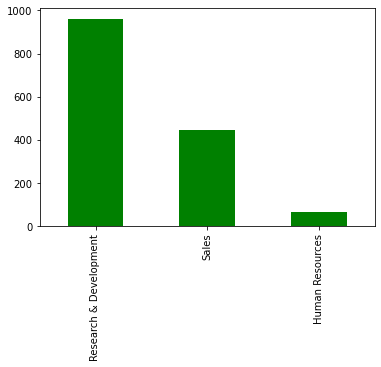

```python
#print(hr_employee_attrition['Department'].value_counts())
print('dtype:                    ',hr_employee_attrition['Department'].dtypes)
print('Research & Development:    {:,.3f}'.format(hr_employee_attrition['Department'].value_counts()[0]/hr_employee_attrition.shape[0]))
print('Sales:                     {:,.3f}'.format(hr_employee_attrition['Department'].value_counts()[1]/hr_employee_attrition.shape[0]))
print('Human Resources:           {:,.3f}'.format(hr_employee_attrition['Department'].value_counts()[2]/hr_employee_attrition.shape[0]))
hr_employee_attrition['Department'].value_counts().plot(kind='bar', color='green')
```

### DistanceFromHome:

- Distance from home.
- Numerical (Continuous).
- Not normally distributed, appears to be skewed towards the right.

```
dtype:  int64
Mean:   9.193
Median: 7.0
Mode:   2
STD:    8.107
Min:    1.000
25%:    2.000
50%:    7.000
75%:    14.000
Max:    29.000
Skew:   0.958
```

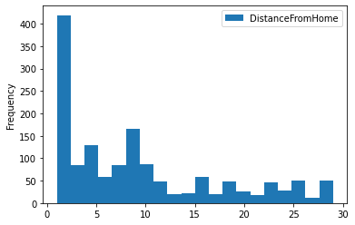

```python
numericalStatsGraphs(['DistanceFromHome'])
```

### Education:

- Education level. (1 = ‘Below College’, 2 = ‘College’, 3 = 'Bachelor', 4 = 'Master', 5 = 'Doctor')
- Categorical (Ordinal).
- There is somc class imbalance.
- Need additional Pre-Processing:
  - Convert from Categorical(Ordinal) to Categorical(Nominal)
  - Dummy/OneHot encoding.

```
dtype:            int64
Bachelor:         0.389
Master:           0.271
College:          0.192
Below College:    0.116
Doctor:           0.033
```

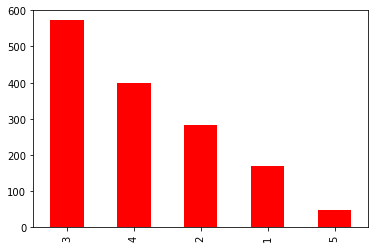

```python
# https://www.kaggle.com/pavansubhasht/ibm-hr-analytics-attrition-dataset
#print(hr_employee_attrition['Education'].value_counts())
print('dtype:           ',hr_employee_attrition['Education'].dtypes)
print('Bachelor:         {:,.3f}'.format(hr_employee_attrition['Education'].astype(str).value_counts()[0]/hr_employee_attrition.shape[0]))
print('Master:           {:,.3f}'.format(hr_employee_attrition['Education'].astype(str).value_counts()[1]/hr_employee_attrition.shape[0]))
print('College:          {:,.3f}'.format(hr_employee_attrition['Education'].astype(str).value_counts()[2]/hr_employee_attrition.shape[0]))
print('Below College:    {:,.3f}'.format(hr_employee_attrition['Education'].astype(str).value_counts()[3]/hr_employee_attrition.shape[0]))
print('Doctor:           {:,.3f}'.format(hr_employee_attrition['Education'].astype(str).value_counts()[4]/hr_employee_attrition.shape[0]))
hr_employee_attrition['Education'].astype(str).value_counts().plot(kind='bar', color='red')
```

### EducationField:

- Field of education. (Human Resources/Life Sciences/Marketing/Medical/Other/Technical Degree).
- Categorical (Nominal).
- There is some class imbalance.
- Need additional Pre-Processing:
  - Dummy/OneHot encoding.

```
dtype:               object
Life Sciences:       0.412
Medical:             0.316
Marketing:           0.108
Technical Degree:    0.090
Other:               0.056
Human Resources:     0.018
```

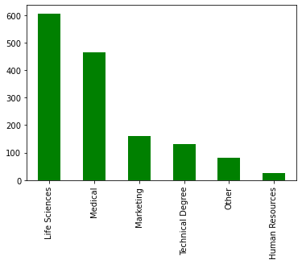

```python
#print(hr_employee_attrition['EducationField'].value_counts())
print('dtype:              ',hr_employee_attrition['EducationField'].dtypes)
print('Life Sciences:       {:,.3f}'.format(hr_employee_attrition['EducationField'].astype(str).value_counts()[0]/hr_employee_attrition.shape[0]))
print('Medical:             {:,.3f}'.format(hr_employee_attrition['EducationField'].astype(str).value_counts()[1]/hr_employee_attrition.shape[0]))
print('Marketing:           {:,.3f}'.format(hr_employee_attrition['EducationField'].astype(str).value_counts()[2]/hr_employee_attrition.shape[0]))
print('Technical Degree:    {:,.3f}'.format(hr_employee_attrition['EducationField'].astype(str).value_counts()[3]/hr_employee_attrition.shape[0]))
print('Other:               {:,.3f}'.format(hr_employee_attrition['EducationField'].astype(str).value_counts()[4]/hr_employee_attrition.shape[0]))
print('Human Resources:     {:,.3f}'.format(hr_employee_attrition['EducationField'].astype(str).value_counts()[5]/hr_employee_attrition.shape[0]))
hr_employee_attrition['EducationField'].astype(str).value_counts().plot(kind='bar', color='green')
```

### EmployeeCount:

- Count of employee per record.
- Numerical (Discrete).
- Although the skew value is 0.000, it is not normally distributed.
- Need additional Pre-Processing:
  - Will be dropped from the dataframe.

```
dtype:  int64
Mean:   1.000
Median: 1.0
Mode:   1
STD:    0.000
Min:    1.000
25%:    1.000
50%:    1.000
75%:    1.000
Max:    1.000
Skew:   0.000
```

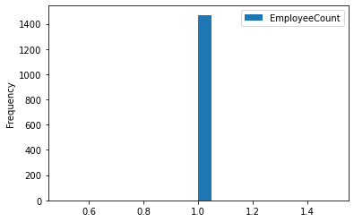

```python
numericalStatsGraphs(['EmployeeCount'])
```

### EmployeeNumber(Index):

- Employee ID #.
- Categorical (Nominal).
- Although the skew value is 0.017, it is not normally distributed.
- Need additional Pre-Processing:
  - Index, will be dropped from the dataframe.

[output not shown]

[output cut: 1425 more lines]

```
 2056
 2057
 2060
 2061
 2062
 2064
 2065
 2068
STD:    602.024
Min:    1.000
25%:    491.250
50%:    1,020.500
75%:    1,555.750
Max:    2,068.000
Skew:   0.017
```

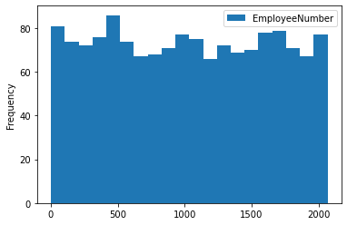

```python
numericalStatsGraphs(['EmployeeNumber'])
```

### EnvironmentSatisfaction:

- Satisfaction with work environment. (1 = 'Low', 2 = 'Medium', 3 = 'High', 4 = 'Very High')
- Categorical (Ordinal).
- Need additional Pre-Processing:
  - Convert from Categorical(Ordinal) to Categorical(Nominal)
  - Dummy/OneHot encoding.

```
dtype:       int64
High:        0.308
Very High:   0.303
Medium:      0.195
Low:         0.193
```

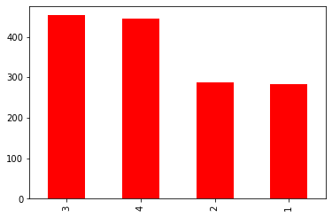

```python
# https://www.kaggle.com/pavansubhasht/ibm-hr-analytics-attrition-dataset
#print(hr_employee_attrition['EnvironmentSatisfaction'].value_counts())
print('dtype:      ',hr_employee_attrition['EnvironmentSatisfaction'].dtypes)
print('High:        {:,.3f}'.format(hr_employee_attrition['EnvironmentSatisfaction'].astype(str).value_counts()[0]/hr_employee_attrition.shape[0]))
print('Very High:   {:,.3f}'.format(hr_employee_attrition['EnvironmentSatisfaction'].astype(str).value_counts()[1]/hr_employee_attrition.shape[0]))
print('Medium:      {:,.3f}'.format(hr_employee_attrition['EnvironmentSatisfaction'].astype(str).value_counts()[2]/hr_employee_attrition.shape[0]))
print('Low:         {:,.3f}'.format(hr_employee_attrition['EnvironmentSatisfaction'].astype(str).value_counts()[3]/hr_employee_attrition.shape[0]))
hr_employee_attrition['EnvironmentSatisfaction'].astype(str).value_counts().plot(kind='bar', color='red')
#hr_employee_attrition['EnvironmentSatisfaction'].plot(kind="hist", bins=20)
```

### Gender:

- Gender (Male or Female)
- Categorical (Nominal).
- Need additional Pre-Processing:
  - Dummy/OneHot encoding.

```
dtype:     object
Male:      0.600
Female:    0.400
```

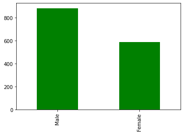

```python
#print(hr_employee_attrition['Gender'].value_counts())
print('dtype:    ',hr_employee_attrition['Gender'].dtypes)
print('Male:      {:,.3f}'.format(hr_employee_attrition['Gender'].astype(str).value_counts()[0]/hr_employee_attrition.shape[0]))
print('Female:    {:,.3f}'.format(hr_employee_attrition['Gender'].astype(str).value_counts()[1]/hr_employee_attrition.shape[0]))
hr_employee_attrition['Gender'].astype(str).value_counts().plot(kind='bar', color='green')
```

### HourlyRate:

- Hourly salary rate.
- Numerical (Continuous).
- Not normally ditributed, appears to be sparsely populated.

```
dtype:  int64
Mean:   65.891
Median: 66.0
Mode:   66
STD:    20.329
Min:    30.000
25%:    48.000
50%:    66.000
75%:    83.750
Max:    100.000
Skew:   -0.032
```

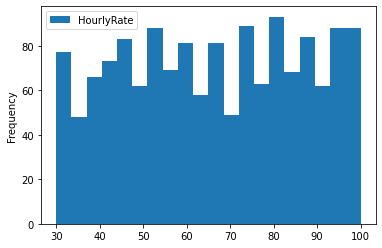

```python
numericalStatsGraphs(['HourlyRate'])
```

### JobInvolvement:

- Job involvement level. (1 = 'Low', 2 = 'Medium', 3 = 'High', 4 = 'Very High').
- Categorical (Ordinal).
- There is some class imbalance.
- Need additional Pre-Processing:
  - Convert from Categorical(Ordinal) to Categorical(Nominal)
  - Dummy/OneHot encoding.

```
dtype:        int64
High:         0.590
Medium:       0.255
Very High:    0.098
Low:          0.056
```

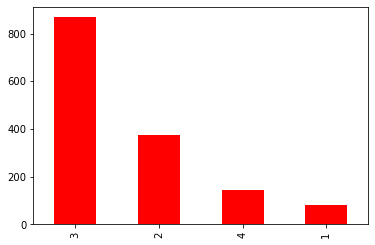

```python
# https://www.kaggle.com/pavansubhasht/ibm-hr-analytics-attrition-dataset
#print(hr_employee_attrition['JobInvolvement'].value_counts())
print('dtype:       ',hr_employee_attrition['JobInvolvement'].dtypes)
print('High:         {:,.3f}'.format(hr_employee_attrition['JobInvolvement'].astype(str).value_counts()[0]/hr_employee_attrition.shape[0]))
print('Medium:       {:,.3f}'.format(hr_employee_attrition['JobInvolvement'].astype(str).value_counts()[1]/hr_employee_attrition.shape[0]))
print('Very High:    {:,.3f}'.format(hr_employee_attrition['JobInvolvement'].astype(str).value_counts()[2]/hr_employee_attrition.shape[0]))
print('Low:          {:,.3f}'.format(hr_employee_attrition['JobInvolvement'].astype(str).value_counts()[3]/hr_employee_attrition.shape[0]))
hr_employee_attrition['JobInvolvement'].astype(str).value_counts().plot(kind='bar', color='red')
#hr_employee_attrition['JobInvolvement'].plot(kind="hist", bins=20)
```

### JobLevel:

- Job level.
- Categorical (Ordinal).
- Not normally distributed, appears to skew to the right.

```
dtype:  int64
Mean:   2.064
Median: 2.0
Mode:   1
STD:    1.107
Min:    1.000
25%:    1.000
50%:    2.000
75%:    3.000
Max:    5.000
Skew:   1.025
```

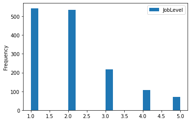

```python
numericalStatsGraphs(['JobLevel'])
```

### JobRole:

- Job role. (Healthcare Representative/Human Resources/Laboratory Technician/Manager/Manufacturing Director/Research Director/Research Scientist/Sales Executive/Sales Representative).
- Categorical (Nominal).
- There is some class imbalance.
- Need additional Pre-Processing:
  - Dummy/OneHot encoding.

```
dtype:                        object
Sales Executive:              0.222
Research Scientist:           0.199
Laboratory Technician:        0.176
Manufacturing Director:       0.099
Healthcare Representative:    0.089
Manager:                      0.069
Sales Representative:         0.056
Research Director:            0.054
Human Resources:              0.035
```

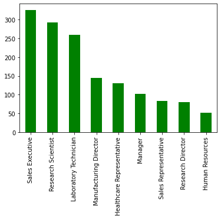

```python
#print(hr_employee_attrition['JobRole'].value_counts())
print('dtype:                       ',hr_employee_attrition['JobRole'].dtypes)
print('Sales Executive:              {:,.3f}'.format(hr_employee_attrition['JobRole'].astype(str).value_counts()[0]/hr_employee_attrition.shape[0]))
print('Research Scientist:           {:,.3f}'.format(hr_employee_attrition['JobRole'].astype(str).value_counts()[1]/hr_employee_attrition.shape[0]))
print('Laboratory Technician:        {:,.3f}'.format(hr_employee_attrition['JobRole'].astype(str).value_counts()[2]/hr_employee_attrition.shape[0]))
print('Manufacturing Director:       {:,.3f}'.format(hr_employee_attrition['JobRole'].astype(str).value_counts()[3]/hr_employee_attrition.shape[0]))
print('Healthcare Representative:    {:,.3f}'.format(hr_employee_attrition['JobRole'].astype(str).value_counts()[4]/hr_employee_attrition.shape[0]))
print('Manager:                      {:,.3f}'.format(hr_employee_attrition['JobRole'].astype(str).value_counts()[5]/hr_employee_attrition.shape[0]))
print('Sales Representative:         {:,.3f}'.format(hr_employee_attrition['JobRole'].astype(str).value_counts()[6]/hr_employee_attrition.shape[0]))
print('Research Director:            {:,.3f}'.format(hr_employee_attrition['JobRole'].astype(str).value_counts()[7]/hr_employee_attrition.shape[0]))
print('Human Resources:              {:,.3f}'.format(hr_employee_attrition['JobRole'].astype(str).value_counts()[8]/hr_employee_attrition.shape[0]))
hr_employee_attrition['JobRole'].astype(str).value_counts().plot(kind='bar', color='green')
```

### JobSatisfaction:

- Satisfaction with job. (1 = 'Low', 2 = 'Medium', 3 = 'High', 4 = 'Very High')
- Categorical (Ordinal).
- Need additional Pre-Processing:
  - Convert from Categorical(Ordinal) to Categorical(Nominal)
  - Dummy/OneHot encoding.

```
dtype:        int64
Very High:    0.312
High:         0.301
Low:          0.197
Medium:       0.190
```

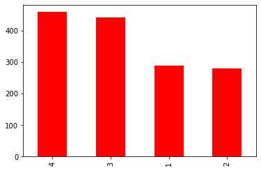

```python
# https://www.kaggle.com/pavansubhasht/ibm-hr-analytics-attrition-dataset
#print(hr_employee_attrition['JobSatisfaction'].value_counts())
print('dtype:       ',hr_employee_attrition['JobSatisfaction'].dtypes)
print('Very High:    {:,.3f}'.format(hr_employee_attrition['JobSatisfaction'].astype(str).value_counts()[0]/hr_employee_attrition.shape[0]))
print('High:         {:,.3f}'.format(hr_employee_attrition['JobSatisfaction'].astype(str).value_counts()[1]/hr_employee_attrition.shape[0]))
print('Low:          {:,.3f}'.format(hr_employee_attrition['JobSatisfaction'].astype(str).value_counts()[2]/hr_employee_attrition.shape[0]))
print('Medium:       {:,.3f}'.format(hr_employee_attrition['JobSatisfaction'].astype(str).value_counts()[3]/hr_employee_attrition.shape[0]))
hr_employee_attrition['JobSatisfaction'].astype(str).value_counts().plot(kind='bar', color='red')
#hr_employee_attrition['JobSatisfaction'].plot(kind="hist", bins=20)
```

### MaritalStatus:

- Marital Status. (Divorced/Married/Single)
- Categorical (Nominal).
- Need additional Pre-Processing:
  - Dummy/OneHot encoding.

```
dtype:       object
Married:     0.458
Single:      0.320
Divorced:    0.222
```

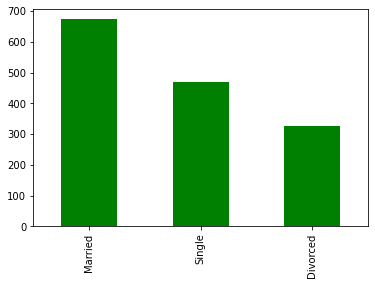

```python
#print(hr_employee_attrition['MaritalStatus'].value_counts())
print('dtype:      ',hr_employee_attrition['MaritalStatus'].dtypes)
print('Married:     {:,.3f}'.format(hr_employee_attrition['MaritalStatus'].astype(str).value_counts()[0]/hr_employee_attrition.shape[0]))
print('Single:      {:,.3f}'.format(hr_employee_attrition['MaritalStatus'].astype(str).value_counts()[1]/hr_employee_attrition.shape[0]))
print('Divorced:    {:,.3f}'.format(hr_employee_attrition['MaritalStatus'].astype(str).value_counts()[2]/hr_employee_attrition.shape[0]))
hr_employee_attrition['MaritalStatus'].astype(str).value_counts().plot(kind='bar', color='green')
```

### MonthlyIncome:

- Monthly income.
- Numerical (Continuous).
- Not normally distributed, appears to be skewed to the right.

```
dtype:  int64
Mean:   6,502.931
Median: 4919.0
Mode:   2342
STD:    4,707.957
Min:    1,009.000
25%:    2,911.000
50%:    4,919.000
75%:    8,379.000
Max:    19,999.000
Skew:   1.370
```

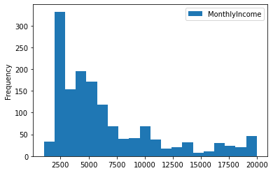

```python
numericalStatsGraphs(['MonthlyIncome'])
```

### MonthlyRate:

- Monthly salary rate.
- Numerical (Continuous).
- Not normally distributed, appears to be sparsely populated.

```
dtype:  int64
Mean:   14,313.103
Median: 14235.5
Mode:   4223
 9150
STD:    7,117.786
Min:    2,094.000
25%:    8,047.000
50%:    14,235.500
75%:    20,461.500
Max:    26,999.000
Skew:   0.019
```

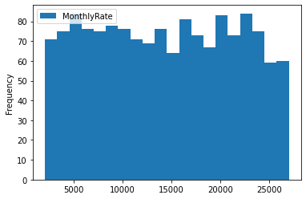

```python
numericalStatsGraphs(['MonthlyRate'])
```

### NumCompaniesWorked:

- Number of companies worked for.
- Numerical (Discrete).
- Not normally distributed, appears to skew to the right.

```
dtype:  int64
Mean:   2.693
Median: 2.0
Mode:   1
STD:    2.498
Min:    0.000
25%:    1.000
50%:    2.000
75%:    4.000
Max:    9.000
Skew:   1.026
```

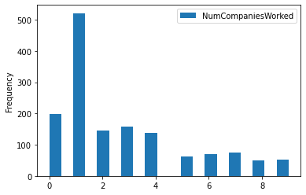

```python
numericalStatsGraphs(['NumCompaniesWorked'])
```

### Over18:

- Employee over 18. (Yes/No).
- Categorical (Nominal).
- There is some class imbalance.
- Need additional Pre-Processing:
  - Will be dropped from the dataframe.

```
dtype:   object
Y:       1.000
```

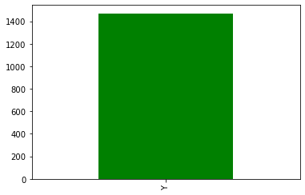

```python
#print(hr_employee_attrition['Over18'].value_counts())
print('dtype:  ',hr_employee_attrition['Over18'].dtypes)
print('Y:       {:,.3f}'.format(hr_employee_attrition['Over18'].astype(str).value_counts()[0]/hr_employee_attrition.shape[0]))
hr_employee_attrition['Over18'].astype(str).value_counts().plot(kind='bar', color='green')
```

### OverTime:

- Overtime (Yes/No).
- Categorical (Nominal).
- There is some class imbalance.
- Need additional Pre-Processing:
  - Dummy/OneHot encoding.

```
dtype:  object
No:     0.717
Yes:    0.283
```

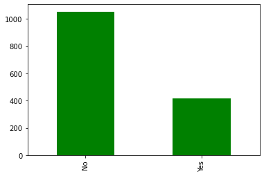

```python
#print(hr_employee_attrition['OverTime'].value_counts())
print('dtype: ',hr_employee_attrition['OverTime'].dtypes)
print('No:     {:,.3f}'.format(hr_employee_attrition['OverTime'].astype(str).value_counts()[0]/hr_employee_attrition.shape[0]))
print('Yes:    {:,.3f}'.format(hr_employee_attrition['OverTime'].astype(str).value_counts()[1]/hr_employee_attrition.shape[0]))
hr_employee_attrition['OverTime'].astype(str).value_counts().plot(kind='bar', color='green')
```

### PercentSalaryHike:

- Percent increase in salary.
- Numerical (Continuous).
- Not normally distributed, appears to skew to the right.

```
dtype:  int64
Mean:   15.210
Median: 14.0
Mode:   11
STD:    3.660
Min:    11.000
25%:    12.000
50%:    14.000
75%:    18.000
Max:    25.000
Skew:   0.821
```

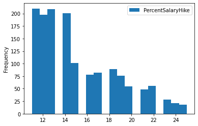

```python
numericalStatsGraphs(['PercentSalaryHike'])
```

### PerformanceRating:

- Employee performance rating. (1 = 'Low', 2 = ‘Good’, 3 = ‘Excellent’, 4 = ‘Outstanding’).
- Categorical (Ordinal).
- There is some class imbalance.
- Need additional Pre-Processing:
  - Convert from Categorical(Ordinal) to Categorical(Nominal)
  - Dummy/OneHot encoding.

```
dtype:          int64
Excellent:      0.846
Outstanding:    0.154
```

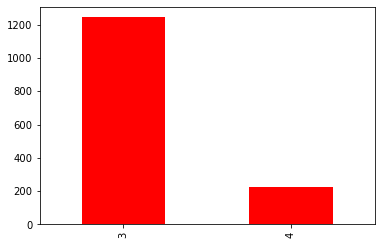

```python
# https://www.kaggle.com/pavansubhasht/ibm-hr-analytics-attrition-dataset
#print(hr_employee_attrition['PerformanceRating'].value_counts())
print('dtype:         ',hr_employee_attrition['PerformanceRating'].dtypes)
print('Excellent:      {:,.3f}'.format(hr_employee_attrition['PerformanceRating'].astype(str).value_counts()[0]/hr_employee_attrition.shape[0]))
print('Outstanding:    {:,.3f}'.format(hr_employee_attrition['PerformanceRating'].astype(str).value_counts()[1]/hr_employee_attrition.shape[0]))
hr_employee_attrition['PerformanceRating'].astype(str).value_counts().plot(kind='bar', color='red')
#hr_employee_attrition['PerformanceRating'].plot(kind="hist", bins=20)
```

### RelationshipSatisfaction:

- Satisfaction with relationship. (1 = 'Low', 2 = 'Medium', 3 = 'High', 4 = 'Very High')
- Categorical (Ordinal).
- Need additional Pre-Processing:
  - Convert from Categorical(Ordinal) to Categorical(Nominal)
  - Dummy/OneHot encoding.

```
dtype:        int64
High:         0.312
Very High:    0.294
Medium:       0.206
Low:          0.188
```

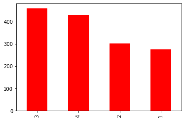

```python
# https://www.kaggle.com/pavansubhasht/ibm-hr-analytics-attrition-dataset
#print(hr_employee_attrition['RelationshipSatisfaction'].value_counts())
print('dtype:       ',hr_employee_attrition['RelationshipSatisfaction'].dtypes)
print('High:         {:,.3f}'.format(hr_employee_attrition['RelationshipSatisfaction'].astype(str).value_counts()[0]/hr_employee_attrition.shape[0]))
print('Very High:    {:,.3f}'.format(hr_employee_attrition['RelationshipSatisfaction'].astype(str).value_counts()[1]/hr_employee_attrition.shape[0]))
print('Medium:       {:,.3f}'.format(hr_employee_attrition['RelationshipSatisfaction'].astype(str).value_counts()[2]/hr_employee_attrition.shape[0]))
print('Low:          {:,.3f}'.format(hr_employee_attrition['RelationshipSatisfaction'].astype(str).value_counts()[3]/hr_employee_attrition.shape[0]))
hr_employee_attrition['RelationshipSatisfaction'].astype(str).value_counts().plot(kind='bar', color='red')
#hr_employee_attrition['RelationshipSatisfaction'].plot(kind="hist", bins=20)
```

### StandardHours:

- Standard number of work hours.
- Numerical (Discrete).
- Although the skew value is 0.000, it is not normally distributed.
- Need additional Pre-Processing:
  - Will be dropped from the dataframe.

```
dtype:  int64
Mean:   80.000
Median: 80.0
Mode:   80
STD:    0.000
Min:    80.000
25%:    80.000
50%:    80.000
75%:    80.000
Max:    80.000
Skew:   0.000
```

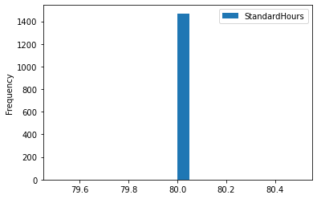

```python
numericalStatsGraphs(['StandardHours'])
```

### StockOptionLevel:

- Stock option level. (0, 1, 2, 3)
- Categorical (Ordinal).
- There is some class imbalance.

```
dtype:     int64
0:         0.429
1:         0.405
2:         0.107
3:         0.058
```

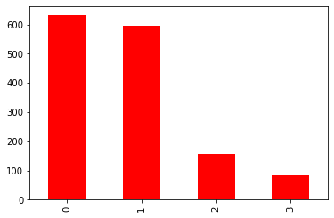

```python
# https://www.kaggle.com/pavansubhasht/ibm-hr-analytics-attrition-dataset
#print(hr_employee_attrition['StockOptionLevel'].value_counts())
print('dtype:    ',hr_employee_attrition['StockOptionLevel'].dtypes)
print('0:         {:,.3f}'.format(hr_employee_attrition['StockOptionLevel'].astype(str).value_counts()[0]/hr_employee_attrition.shape[0]))
print('1:         {:,.3f}'.format(hr_employee_attrition['StockOptionLevel'].astype(str).value_counts()[1]/hr_employee_attrition.shape[0]))
print('2:         {:,.3f}'.format(hr_employee_attrition['StockOptionLevel'].astype(str).value_counts()[2]/hr_employee_attrition.shape[0]))
print('3:         {:,.3f}'.format(hr_employee_attrition['StockOptionLevel'].astype(str).value_counts()[3]/hr_employee_attrition.shape[0]))
hr_employee_attrition['StockOptionLevel'].astype(str).value_counts().plot(kind='bar', color='red')
#hr_employee_attrition['StockOptionLevel'].plot(kind="hist", bins=20)
```

### TotalWorkingYears:

- Number of years working.
- Numerical (Discrete).
- Not normally distributed, appears to skew to the right.

```
dtype:  int64
Mean:   11.280
Median: 10.0
Mode:   10
STD:    7.781
Min:    0.000
25%:    6.000
50%:    10.000
75%:    15.000
Max:    40.000
Skew:   1.117
```

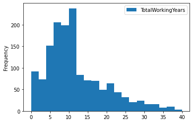

```python
numericalStatsGraphs(['TotalWorkingYears'])
```

### TrainingTimesLastYear:

- Number of hours training last year.
- Numerical (Discrete).
- Not normally distributed, appears to skew to the right.

```
dtype:  int64
Mean:   2.799
Median: 3.0
Mode:   2
STD:    1.289
Min:    0.000
25%:    2.000
50%:    3.000
75%:    3.000
Max:    6.000
Skew:   0.553
```

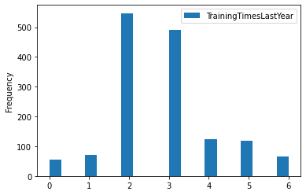

```python
numericalStatsGraphs(['TrainingTimesLastYear'])
```

### WorkLifeBalance:

- Balance between work and life. (1 = 'Bad', 2 = 'Good', 3 = 'Better', 4 = 'Best').
- Categorical (Ordinal).
- There is some class imbalance.
- Need additional Pre-Processing:
  - Convert from Categorical(Ordinal) to Categorical(Nominal)
  - Dummy/OneHot encoding.

```
dtype:   int64
Better:  0.607
Good:    0.234
Best:    0.104
Bad:     0.054
```

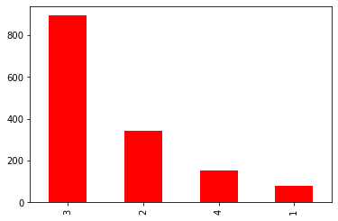

```python
# https://www.kaggle.com/pavansubhasht/ibm-hr-analytics-attrition-dataset
#print(hr_employee_attrition['WorkLifeBalance'].value_counts())
print('dtype:  ',hr_employee_attrition['WorkLifeBalance'].dtypes)
print('Better:  {:,.3f}'.format(hr_employee_attrition['WorkLifeBalance'].astype(str).value_counts()[0]/hr_employee_attrition.shape[0]))
print('Good:    {:,.3f}'.format(hr_employee_attrition['WorkLifeBalance'].astype(str).value_counts()[1]/hr_employee_attrition.shape[0]))
print('Best:    {:,.3f}'.format(hr_employee_attrition['WorkLifeBalance'].astype(str).value_counts()[2]/hr_employee_attrition.shape[0]))
print('Bad:     {:,.3f}'.format(hr_employee_attrition['WorkLifeBalance'].astype(str).value_counts()[3]/hr_employee_attrition.shape[0]))
hr_employee_attrition['WorkLifeBalance'].astype(str).value_counts().plot(kind='bar', color='red')
#hr_employee_attrition['WorkLifeBalance'].plot(kind="hist", bins=20)
```